# breast cancer mutant example

first need to install OCTAD desktop (https://github.com/Bin-Chen-Lab/octad_desktop) The only variable which needs to be changed is “base.folder”. If the user’s file structure matches the example, other variables are generated automatically.

```r
start.time <- Sys.time()
# knitr::opts_knit$set(root.dir = '../..')
base.folder <- '~/Documents/stanford/tumor_cell_line/pipeline/octad_desktop/' # should be set to installation parent folder
setwd(base.folder)

library(dplyr)
library(ggplot2)
library("RUVSeq")
library("GSVA")
library(compiler)
library(data.table)
library(devtools)
library(limma)
library(rhdf5)
# library(doParallel)


#enableJIT(3)


# iteration = 1 # don't touch this. Below automatically increases "iteration" upon detection of previous runs.
# for (i in 1:length(dir(normalizePath('./results/')))) {
# if (dir.exists(paste0(normalizePath(paste0('./results/results_',Sys.Date(),'_',i,'/')),'/'))==TRUE)
#   iteration = iteration + 1
# }

outputFolder = '~/Documents/stanford/grant/2019/ot2/work/data/results/BRAC_positive/'
if (!dir.exists(outputFolder)) {
  dir.create(outputFolder)
}
#outputFolder = paste0(normalizePath(paste0('./results/results_',Sys.Date(),'_',iteration,'/')),'/')
dataFolder = '~/Documents/stanford/tumor_cell_line/pipeline/octad_desktop/data/'
CodeFolder = '~/Documents/stanford/tumor_cell_line/pipeline/octad_desktop/code/'
dataFolder
```

```
## [1] "~/Documents/stanford/tumor_cell_line/pipeline/octad_desktop/data/"
```

```r
CodeFolder
```

```
## [1] "~/Documents/stanford/tumor_cell_line/pipeline/octad_desktop/code/"
```

```r
load(paste0(dataFolder,'metadata.RData')) # loads 'ensemble_info', 'merged_gene_info', 'breastpam50', 'tsne', and 'phenoDF'

source(paste0(CodeFolder,'core_functions.R'))

# avoiding logging errors
tsne.time    <- "Not run"
GEA.time     <- "Not run"
VDH.time     <- "Not run"
enrich.time  <- "Not run"
ranking.time <- "Not run"
```

Here, you will normalize samples for batch effects with package “RUVSeq”. You can set it off by changing set parameters script.  
Set parameters. Below are default settings. You can set normalize_samples = F to make it run faster at risk of batch effects.

```r
setwd(base.folder)
# DE params:
normalize_samples = T
k = 1
n_topGenes = 10000
#this demo sample set does not have too much genes. The usual default for n_topGenes = 10000. Set this higher if you think there are more significant genes
DE_method = 'edgeR' # Other choice is 'limma' 'DESeq'


# disease signature params:
log2fchange <- 2 # the cutoff for "significant gene impact". Default = 1, so any DE gene with log2foldchange < 1 will be omitted. Improved results with 2.
padjusted <- 0.001 # the cutoff for "significant genes". Default = 0.001, so any DE genes with padj > 0.001 will be omitted.


# sRGES params:
# Only mess with "max_gene_size", which is how many up-regulated genes and down-regulated genes are allowed. ("100" = 100up + 100down = 200 total)
landmark = 1
choose_fda_drugs = F
max_gene_size = 100
weight_cell_line = F

# logging parameters
write('x', file = paste0(outputFolder,"parameters.txt"))
fileConn<-file(paste0(outputFolder,"parameters.txt"))
writeLines(c("Normalization Parameters:","normalize_samples",normalize_samples,"","k",k,"","n_topGenes",n_topGenes,"","DE_method",DE_method,"","--------------------------","","Disease Signature Parameters:","log2fchange",log2fchange,"","padjusted",padjusted,"","--------------------------","","sRGES Parameters:","landmark",landmark,"","choose_fda_drugs",choose_fda_drugs,"","max_gene_size",max_gene_size,"","weight_cell_line",weight_cell_line), fileConn)
close(fileConn)
```

Have the following files in your dataFolder:

- metadata.RData
- octad.h5 [expression data]
- cmpd_sets_chembl_targets.RData
- cmpd_sets_mesh.RData
- cmpd_sets_meshes.RData
- cmpd_sets_sea_targets.RData
- cmpd_sets_ChemCluster.RData
- encoderDF_AEmodel1.RData
- lincs_sig_info.csv
- lincs_signatures_cmpd_landmark_symbol.RData
- CCLE_OCTAD.RData
- repurposing_drugs_20170327.csv
- metadata.RData

Have the following scripts in your CodeFolder:

- [your workflow].Rmd (this Rmd is an example)
- core_functions.R

Load the dataframes that contain your case and normal reference tissues.  
DO NOT VIEW these dataframes. They’re too large. Use the colnames, rownames, and dim functions. Otherwise, you may crash.

```r
data.load.start <- Sys.time()
load(paste0(dataFolder,'encoderDF_AEmodel1.RData')) # only need to load this if you are using EncoderDF.

#the phenotype dataframe is called phenoDF, loaded earlier via metadata.RData

data.load.end  <- Sys.time()
data.load.time <- data.load.end - data.load.start
data.load.time
```

```
## Time difference of 0.08696198 secs
```

***Read in Mutant data

```r
mutDF = read.csv(paste0(dataFolder,'TCGA_MET500_LONG.csv'),
                 stringsAsFactors = F, header = F)
```

##Select Cases##

```r
#setwd(base.folder)
case.load.start <- Sys.time()

phenoDF_case   <- phenoDF %>% filter(cancer == 'Breast Invasive Carcinoma', sample.type != 'adjacent', data.source == 'TCGA', gender == 'Female')
mut_only       <- (mutDF %>% filter(V2 %in% c('BRCA1', 'BRCA2')))$V1 # change gene to your mutation of interest
phenoDF_case <- phenoDF_case %>% filter(sample.id %in% mut_only)

# Example where we subset phenoDF to only include samples from certain sites of interest. Useful when computeRefTissue is unlikely to work.
# skin sample example
# condinfo     <- grep('^SKIN',phenoDF$biopsy.site)
# skin.samples <- phenoDF$sample.id[condinfo]
# tcgaskinids  <- (phenoDF %>% filter(cancer == 'Skin Cutaneous Melanoma'))$sample.id
# gtexskinids  <- (phenoDF %>% filter(cancer == 'normal',sample.id %in% skin.samples))$sample.id
# all.samples  <- c(unlist(tcgaskinids), unlist(gtexskinids))
# phenoDF_skin <- phenoDF[phenoDF$sample.id %in% all.samples,]
# phenoDF_case <- phenoDF_skin %>%
#   filter(cancer == 'Skin Cutaneous Melanoma',
#          sample.type %in% c('metastatic'))
# case.cancer <- c('Cutaneous Melanoma','Head And Neck Mucosal Melanoma','Skin Cutaneous Melanoma')
# phenoDF_case <- phenoDF %>%
#   filter(cancer %in% case.cancer,
#          sample.type %in% c('metastatic'))
```

Create a list with sample IDs for the cancer of interest (case).

```r
case_id <- phenoDF_case$sample.id
write.csv(phenoDF_case, file = paste0(outputFolder,'case_ids.csv'))
```

Results: **17** case IDs.  
***

##Select Reference Control Samples##  
*** Identify the sample.id of normal tissues in the phenoDF. They should be from the GTEX database and contain “GTEX…” in the start of the sample ID name.

```r
setwd(base.folder)
phenoDF_Female <- phenoDF %>% filter(gender == "Female")
normal_id = (phenoDF_Female %>% filter(data.source == 'GTEX',biopsy.site== 'BREAST - MAMMARY TISSUE'))$sample.id

#filter the biopsy.site to compare only the tissues in breast

# selecting pool of normal samples with similar (but not identical) names:
# normal_id = (phenoDF_skin %>% filter(data.source == 'GTEX'))$sample.id
# all.mitf <- subset(df,rownames(df) %in% all.samples)
# all.mitf.pheno <- merge(x=all.mitf,y=phenoDF[,c('sample.id','sample.type','biopsy.site')],by.x="row.names",by.y="sample.id", allx=TRUE)


# if including adjacents:
# normal_id = c(normal_id,(phenoDF %>% filter(sample.type == 'adjacent'))$sample.id)
```

Define normal and case counts. Combine the normal and case counts by generating a table called dz_expr containing columns of normal and case sample IDs vs rows of genes.

```r
normal_counts = EncoderDF[,normal_id]
case_counts = EncoderDF[,case_id]

(row.names(case_counts) == row.names(normal_counts)) %>% sum() # should be 64
```

```
## [1] 64
```

```r
#quick check to see that all genes match up before combining

dz_expr = cbind(normal_counts, case_counts)

rm(normal_counts, case_counts) # free up some memory

dim(dz_expr)
```

```
## [1] 64 96
```

Define your control ID–the control samples you are comparing your case with. The computeRefTussue function will match similar normal samples to your chosen cancer. This function is based on mRNA data of high varying expression across all tissues.  
You will generate **50** control samples, unless you state a different control_size.

```r
control_id <- computeRefTissue(case_id = case_id, #computes ref tissue given case_id, normal_id chr vectors
                               normal_id = normal_id,
                               expSet = dz_expr, #expSet is a counts dataframe that contains both case and normal counts.
                               control_size = 50)
write(control_id, file = paste0(outputFolder,'control_ids.txt'))
#this function will also generate a csv called case_normal_median_cor.csv that includes the median correlation of each normal sample.
normCor = read.csv(paste0(outputFolder,'case_normal_median_cor.csv'),stringsAsFactors = F)
normCor = normCor %>% inner_join(phenoDF,by='sample.id')
```

```r
rhdf5_file <- paste0(dataFolder, "octad.h5")
#h5createFile(rhdf5_file)
transcripts = as.character(h5read(rhdf5_file, "meta/transcripts"))
samples = as.character(h5read(rhdf5_file, "meta/samples"))
case_counts = h5read(rhdf5_file, "data/count", index=list(1:length(transcripts), which(samples %in% case_id)))
colnames(case_counts) = samples[samples %in% case_id]
rownames(case_counts) = transcripts
case_id = samples[samples %in% case_id]
normal_counts = h5read(rhdf5_file, "data/count", index=list(1:length(transcripts), which(samples %in% control_id)))
colnames(normal_counts) = samples[samples %in% control_id]
rownames(normal_counts) = transcripts
control_id = samples[samples %in% control_id]
H5close()

dz_expr = cbind(normal_counts, case_counts)
rm(normal_counts) # free up some memory
```

Check the tissue location of where the control samples are from.

```r
(phenoDF %>% filter(sample.id %in% control_id) %>% select(biopsy.site) %>% table())
```

```
## .
## BREAST - MAMMARY TISSUE
##                      50
```

If I want, I can exclude certain samples. ***

##Visualization of Case Vs. Reference Samples##  
***

To see how similar the controls are to the case samples, get the correlations of mRNA expressions between each of the normal samples and the set of cases. The list is in descending order.

```r
setwd(base.folder)
normCor <- normCor %>% arrange(desc(cor))

head(normCor)
```

```
##                  sample.id       cor sample.type             biopsy.site cancer
## 1  GTEX-S341-1526-SM-4AD6K 0.3440018      normal BREAST - MAMMARY TISSUE normal
## 2 GTEX-13FTY-2226-SM-5J1ND 0.3341575      normal BREAST - MAMMARY TISSUE normal
## 3  GTEX-YFC4-1426-SM-5IFJG 0.3148810      normal BREAST - MAMMARY TISSUE normal
## 4  GTEX-T5JW-2026-SM-4DM63 0.3081044      normal BREAST - MAMMARY TISSUE normal
## 5  GTEX-XUZC-1626-SM-4BRVP 0.3077381      normal BREAST - MAMMARY TISSUE normal
## 6  GTEX-Y3IK-2326-SM-4WWDT 0.2898810      normal BREAST - MAMMARY TISSUE normal
##   data.source gender read.count.file
## 1        GTEX Female      TOIL.RData
## 2        GTEX Female      TOIL.RData
## 3        GTEX Female      TOIL.RData
## 4        GTEX Female      TOIL.RData
## 5        GTEX Female      TOIL.RData
## 6        GTEX Female      TOIL.RData
```

Goal is to sort the correlation order based on tissue type.  
***

1. Find median correlation for each primary site

```r
(reference_tissue_rank <- normCor %>%
  group_by(biopsy.site) %>% summarise(medianCor = median(cor)) %>%
  ungroup())
```

```
## # A tibble: 1 x 2
##   biopsy.site             medianCor
##   <chr>                       <dbl>
## 1 BREAST - MAMMARY TISSUE     0.199
```

2. Sort the median correlation of the different tissues from high to low

```r
setwd(base.folder)
(top_refs = reference_tissue_rank %>% arrange(desc(medianCor)))
```

```
## # A tibble: 1 x 2
##   biopsy.site             medianCor
##   <chr>                       <dbl>
## 1 BREAST - MAMMARY TISSUE     0.199
```

```r
#top_refs <-  reference_tissue_rank[1:10, 1]
```

3. Sort tissue from high to low correlation. Top ten shown.

```r
setwd(base.folder)
normCor$ref <- factor(normCor$biopsy.site, levels = top_refs$biopsy.site)
levels(normCor$ref)[1:10]
```

```
##  [1] "BREAST - MAMMARY TISSUE" NA
##  [3] NA                        NA
##  [5] NA                        NA
##  [7] NA                        NA
##  [9] NA                        NA
```

```r
(top_refs = reference_tissue_rank %>% arrange(desc(medianCor)))
```

```
## # A tibble: 1 x 2
##   biopsy.site             medianCor
##   <chr>                       <dbl>
## 1 BREAST - MAMMARY TISSUE     0.199
```

```r
normCor$ref <- factor(normCor$biopsy.site, levels = top_refs$biopsy.site)
normCor$control <- NA
normCor$control[1:50] <- 'control'
top10 = levels(normCor$ref)[1:10]
```

4. Graph tissue type vs mRNA correlation

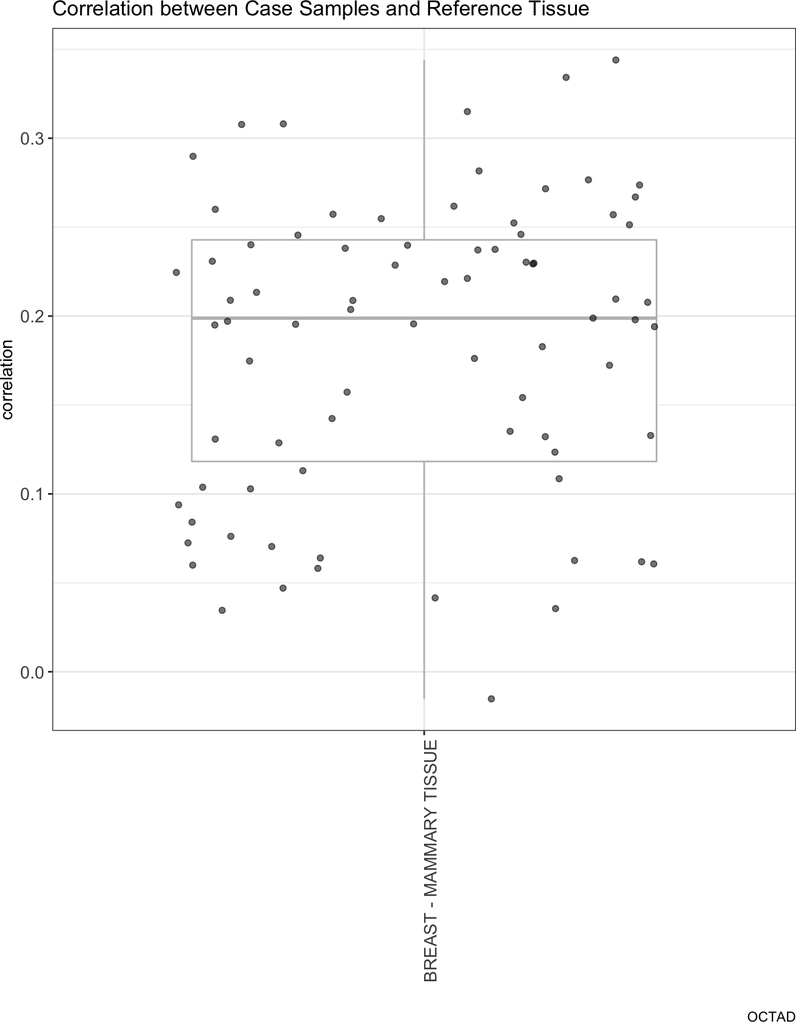

```r
p <- ggplot(normCor, aes(ref, cor))
p +   geom_boxplot(color='grey', notch=F, outlier.shape = NA) +
  geom_jitter(aes(alpha=1/100), show.legend = F) +
  theme_bw() +
  ylab("correlation") +
  xlab("") +
  labs (title='Correlation between Case Samples and Reference Tissue',caption='OCTAD')+
  theme(axis.text.x = element_text(angle = 90, hjust = 1, size = 11),
  axis.text.y = element_text(size = 11), axis.title = element_text(size = 11),
  plot.margin = margin(l=0))
```

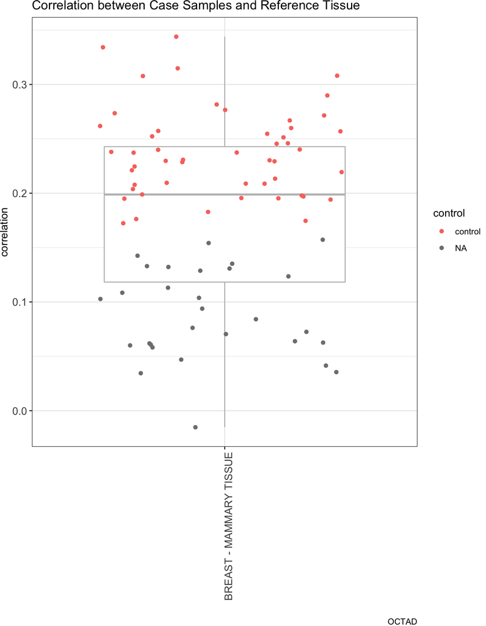

```r
p <- ggplot(normCor %>% filter(ref %in% top10), aes(ref, cor))
p +   geom_boxplot(color='grey', notch=F, outlier.shape = NA) + geom_jitter(aes(color=control)) +
  #geom_jitter(aes(alpha=1/100), show.legend = F) +
  theme_bw() +
  ylab("correlation") +
  xlab("") +
  labs (title='Correlation between Case Samples and Reference Tissue',caption='OCTAD')+
  theme(axis.text.x = element_text(angle = 90, hjust = 1, size = 11),
  axis.text.y = element_text(size = 11), axis.title = element_text(size = 11),
  plot.margin = margin(l=0))
```

```r
ggsave('correlation graph.pdf', paper='a4r', path=outputFolder)
```

##Visualize on Cancer Map## Optional case-control visualization.

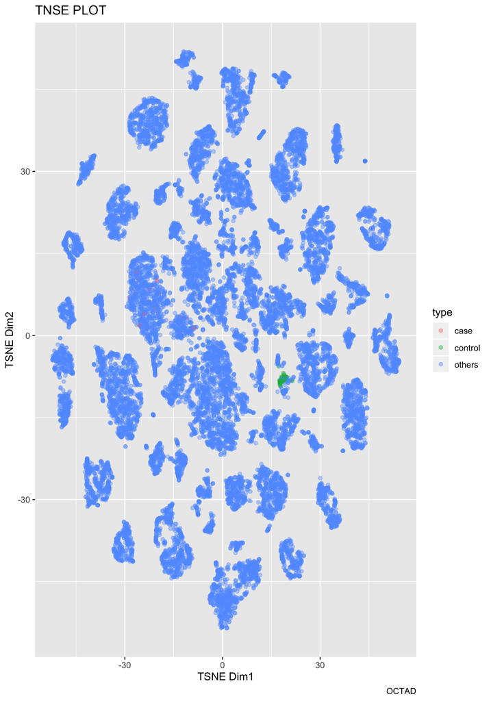

```r
#optional - duration: approximately 3 seconds
setwd(base.folder)

tsne.time.start <- Sys.time()

#make a new column called type to state case, control, or others
tsne$type <- "others"
tsne$type[tsne$sample.id %in% case_id] <- "case"
tsne$type[tsne$sample.id %in% control_id] <- "control"

#plot
(p2 <- ggplot(tsne, aes(X, Y, color = type)) + geom_point(alpha = 0.4)+
    labs(title = paste ('TNSE PLOT'), x= 'TSNE Dim1', y='TSNE Dim2', caption="OCTAD"))
```

```r
ggsave("case_control_map.pdf", path=outputFolder)
tsne.time.stop <- Sys.time()
tsne.time <- tsne.time.stop - tsne.time.start
tsne.time
```

```
## Time difference of 1.7518 secs
```

##Optional: Selecting Another Set of Reference Samples##  
***

```r
#optional
#2a. select normals based on the top site computed e.g. if brain was top site select all brain as controls
#2b. select normals based on the top primary site
  #note there are subtypes of which brain sites are there
  #instead of all brain sites we can select the part with highest correlation
    #e.g. cortex, medulla etc...
#2c. change the graph to plot more specific sites mentioned in 2b.

#rm(p,normal_median_cor,phenoDF,phenoDF_case,reference_tissue_rank,top_refs) before selecting another set.
```

##Run Differential Expressions##

Variables needed:

- case_id : samples IDs of case tissues in a character vector
- control_id : samples IDs of control tissues in a character vector
- dz_expr : dataframe that contains both case_id and control_id in its column names,
- outputFolder : folder to place output files

Read csv with gene information and read Diff_Exp.R script.  
This will output 3 files: “computedEmpGenes.csv”, “DE_genes.csv”, and “highExpGenes.csv”.

```r
DE.start <- Sys.time()


# important that the below res is generated LAST.
res = diffExp(case_id = case_id,
        control_id = control_id,
        expSet = dz_expr,
        normalize_samples = normalize_samples,
        k=k,
        n_topGenes=n_topGenes,
        DE_method=DE_method
        )
```

```
## [1] "computing DE via edgeR"
```

```r
DE.end <- Sys.time()
DE.time <- DE.end - DE.start
DE.time
```

```
## Time difference of 34.27295 secs
```

##Disease Signature##  
***

Get the disease signature.

```r
dz_signature <- res %>% filter(padj < padjusted, abs(log2FoldChange)>log2fchange)
#filter out res df to get dz sigs
#Term res refers to the results table that is generated from the Diff_Exp. R script.
dim(dz_signature)
```

```
## [1] 1986    6
```

```r
head(dz_signature)
```

```
##        identifier log2FoldChange     logCPM        LR       pvalue         padj
## 1 ENSG00000000005      -4.057285  2.3886568  36.55013 1.487900e-09 2.076661e-05
## 2 ENSG00000001630       2.055296  6.2082700  30.54241 3.266472e-08 4.303576e-04
## 3 ENSG00000002746      -2.002458 -0.1989167  31.36436 2.138708e-08 2.838279e-04
## 4 ENSG00000003096      -2.442860  4.1856075  30.91148 2.700691e-08 3.569773e-04
## 5 ENSG00000003249       2.927472  4.2264032 138.54057 5.550958e-32 9.801881e-28
## 6 ENSG00000004478       2.098563  7.3785022 102.70753 3.884643e-24 6.717325e-20
```

Combine the res table with the Ensembl table to generate a differential expression results table with gene information.

```r
res_geneinfo <- left_join(res, merged_gene_info, by=c('identifier'='ensembl'))
write.csv(res_geneinfo,file=paste0(outputFolder,'res_geneinfo.csv'))
```

Generate table for disease signature

```r
dz_signature <- dz_signature %>% left_join(ensembl_info %>% select(gene,ensembl,chrom,strand),
                                           by=c('identifier'='ensembl'))
dim(dz_signature)
```

```
## [1] 1986    9
```

```r
head(dz_signature)
```

```
##        identifier log2FoldChange     logCPM        LR       pvalue         padj
## 1 ENSG00000000005      -4.057285  2.3886568  36.55013 1.487900e-09 2.076661e-05
## 2 ENSG00000001630       2.055296  6.2082700  30.54241 3.266472e-08 4.303576e-04
## 3 ENSG00000002746      -2.002458 -0.1989167  31.36436 2.138708e-08 2.838279e-04
## 4 ENSG00000003096      -2.442860  4.1856075  30.91148 2.700691e-08 3.569773e-04
## 5 ENSG00000003249       2.927472  4.2264032 138.54057 5.550958e-32 9.801881e-28
## 6 ENSG00000004478       2.098563  7.3785022 102.70753 3.884643e-24 6.717325e-20
##      gene chrom strand
## 1    TNMD  chrX      +
## 2 CYP51A1  chr7      -
## 3   HECW1  chr7      +
## 4  KLHL13  chrX      -
## 5  DBNDD1 chr16      -
## 6   FKBP4 chr12      +
```

```r
#the column name may differ between different metadata but you need Symbol to join with RGES
dz_signature$Symbol <- toupper(dz_signature$gene)
str(dz_signature$Symbol)
```

```
##  chr [1:1986] "TNMD" "CYP51A1" "HECW1" "KLHL13" "DBNDD1" "FKBP4" "HSPB6" ...
```

```r
write.csv(dz_signature, paste0(outputFolder, "/dz_signature.csv"),row.names = F)
```

##Affected Pathways and Potential Drugs for Reversal##  
*** Find potential drugs that may reverse disease signature. Takes ~10mins to run following chunk. Following scripts will output “all_lincs_score.csv”" and “sRGES.csv”.  
File all_lincs_score.csv has the RGES (reversal gene expression score), which is needed for the gene_enrichment_analysis script later.  
File sRGES.csv is the summarized RGES.

```r
setwd(base.folder)
sRGES.start <- Sys.time()
# source(paste0(CodeFolder,'core_functions.R'))
#functions needed to run RGES
# source(paste0(CodeFolder,'runRGES_dz_arrangeMax_compiler.R'))
runsRGES(
  dz_signature = dz_signature,
  choose_fda_drugs = choose_fda_drugs,
  parallel = F,                         # causes issues for some machines.
  max_gene_size = max_gene_size,
  landmark = landmark
  )
sRGES.end <- Sys.time()
sRGES.time <- sRGES.end - sRGES.start
sRGES.time
```

```
## Time difference of 8.408987 mins
```

See which pathways are affected by running following code. This results the up-regulated pathways as “dz_up_sig_genes_enriched.csv” and the down-regulated pathways as “dz_dn_sig_genes_enriched.csv”.

```r
#optional
setwd(base.folder)
GEA.time.start <- Sys.time()

visualize_dz_sig_pathway()
```

```
## [1] "GO_Biological_Process_2017" "GO_Cellular_Component_2017"
## [3] "KEGG_2016"
```

```r
visualize_dz_sig(case_id = case_id,
                 control_id = control_id)

GEA.time.stop <- Sys.time()
GEA.time <- GEA.time.stop - GEA.time.start
GEA.time
```

```
## Time difference of 5.200204 secs
```

Ouput the "lincs_reverse_expression.pdf’ containing a heatmap showing drug hits and their effects on mRNA expression.

```r
#optional - duration: approximately 5 seconds
setwd(base.folder)
VDH.time.start <- Sys.time()
# source(paste0(CodeFolder,'visualize_drug_hits.R'))
visualize_drug_hits()
```

```r
VDH.time.stop <- Sys.time()
VDH.time <- VDH.time.stop - VDH.time.start
VDH.time
```

```
## Time difference of 5.198242 secs
```

## Find best cell line & Validate with cell line data in silico

```r
#optional - Duration: approximately 20 seconds.
setwd(base.folder)
ranking.time.start  <- Sys.time()

topline <- computeCellLine(case_id = case_id,
                           expSet = dz_expr,
                           LINCS_overlaps = T)

topLineEval(topline = topline)

ranking.time.stop  <- Sys.time()
ranking.time <- ranking.time.stop - ranking.time.start
ranking.time
```

```
## Time difference of 39.49512 secs
```

##Platform and packages used in analysis##

```r
setwd(base.folder)
writeLines(capture.output(sessionInfo()), paste0(outputFolder,"session_info.txt"))
```

##Time Logging##

```r
setwd(base.folder)
end.time <- Sys.time()

total.time <- end.time - start.time
total.time
```

```
## Time difference of 10.54443 mins
```

```r
write('x', file = paste0(outputFolder,"time_log.txt"))
fileConn<-file(paste0(outputFolder,"time_log.txt"))
writeLines(c(
  "Time Log (in seconds, minutes, or hours)","",
  "Total Time",total.time,"",
  "Data Load Time", data.load.time,"",
  "tSNE Time",tsne.time,"",
  "DE Time",DE.time,"",
  "sRGES Time",sRGES.time,"",
  "Enrich Time",enrich.time,"",
  "GEA Time",GEA.time,"",
  "Visualize Hits Time",VDH.time,"",
  "Ranking Time",ranking.time),
  fileConn)
close(fileConn)
```

[output not shown]